# Understandin Linear Models

# Introduction

In this document, we will provide a detailed worked example of a linear model. We will illustrate the null hypotheses that appear in the summary of the model, how to compute the design matrix, the interpretation of the residual standard error, the null hypothesis of the F-statistic, the degrees of freedom, how to predict new values, and other relevant aspects to understand a linear model.

# Load Required Libraries

```r
# Load necessary libraries
library(ggplot2)
```

We will use the mtcars dataset, which is included in the datasets package in R. This dataset contains information about various car models.

```r
# Load the mtcars dataset
data("mtcars")

# Display the first few rows of the dataset
head(mtcars)
```

```
##                    mpg cyl disp  hp drat    wt  qsec vs am gear carb
## Mazda RX4         21.0   6  160 110 3.90 2.620 16.46  0  1    4    4
## Mazda RX4 Wag     21.0   6  160 110 3.90 2.875 17.02  0  1    4    4
## Datsun 710        22.8   4  108  93 3.85 2.320 18.61  1  1    4    1
## Hornet 4 Drive    21.4   6  258 110 3.08 3.215 19.44  1  0    3    1
## Hornet Sportabout 18.7   8  360 175 3.15 3.440 17.02  0  0    3    2
## Valiant           18.1   6  225 105 2.76 3.460 20.22  1  0    3    1
```

# Fit a Linear Model

We will fit a linear model to predict mpg (miles per gallon) based on wt (weight) and hp (horsepower).

```r
# Fit linear model
lm_model <- lm(mpg ~ wt + hp, data = mtcars)

# Display the summary of the model
summary(lm_model)
```

```
##
## Call:
## lm(formula = mpg ~ wt + hp, data = mtcars)
##
## Residuals:
##    Min     1Q Median     3Q    Max
## -3.941 -1.600 -0.182  1.050  5.854
##
## Coefficients:
##             Estimate Std. Error t value Pr(>|t|)
## (Intercept) 37.22727    1.59879  23.285  < 2e-16 ***
## wt          -3.87783    0.63273  -6.129 1.12e-06 ***
## hp          -0.03177    0.00903  -3.519  0.00145 **
## ---
## Signif. codes:  0 '***' 0.001 '**' 0.01 '*' 0.05 '.' 0.1 ' ' 1
##
## Residual standard error: 2.593 on 29 degrees of freedom
## Multiple R-squared:  0.8268, Adjusted R-squared:  0.8148
## F-statistic: 69.21 on 2 and 29 DF,  p-value: 9.109e-12
```

# Null Hypotheses in the Summary

In the summary of the linear model, the null hypotheses are as follows:

- For each coefficient (intercept, wt, hp): The null hypothesis is that the coefficient is equal to zero (i.e., the variable has no effect on the response variable mpg).
- For the F-statistic: The null hypothesis is that all the regression coefficients are equal to zero (i.e., the model with predictors wt and hp does not explain more variability than the model with only the intercept).

# Design Matrix

The design matrix (also known as the model matrix) is a matrix that contains the values of the predictor variables for each observation. We can compute the design matrix using the model.matrix function.

```r
# Compute the design matrix
design_matrix <- model.matrix(lm_model)

# Display the design matrix
head(design_matrix)
```

```
##                   (Intercept)    wt  hp
## Mazda RX4                   1 2.620 110
## Mazda RX4 Wag               1 2.875 110
## Datsun 710                  1 2.320  93
## Hornet 4 Drive              1 3.215 110
## Hornet Sportabout           1 3.440 175
## Valiant                     1 3.460 105
```

# Interpretation of the Residual Standard Error

The residual standard error (RSE) is an estimate of the standard deviation of the residuals (errors). It gives us an idea of the typical size of the residuals. In the summary of the linear model, the RSE is reported along with the degrees of freedom.

# Null Hypothesis of the F-statistic

The null hypothesis of the F-statistic is that all the regression coefficients are equal to zero. In other words, the model with predictors wt and hp does not explain more variability in mpg than the model with only the intercept.

# Degrees of Freedom

The degrees of freedom for the residuals (df) are calculated as the number of observations minus the number of estimated parameters. In our model, we have 32 observations and 3 estimated parameters (intercept, wt, hp), so the degrees of freedom are 32 - 3 = 29.

# Predicting New Values

We can use the fitted linear model to predict mpg for new values of wt and hp.

```r
# New data for prediction
new_data <- data.frame(wt = c(3, 4), hp = c(110, 150))

# Predict new values
predictions <- predict(lm_model, newdata = new_data)

# Display predictions
predictions
```

```
##        1        2
## 22.09875 16.95001
```

# Visualizing the Model

We can visualize the relationship between mpg and the predictors wt and hp using ggplot2.

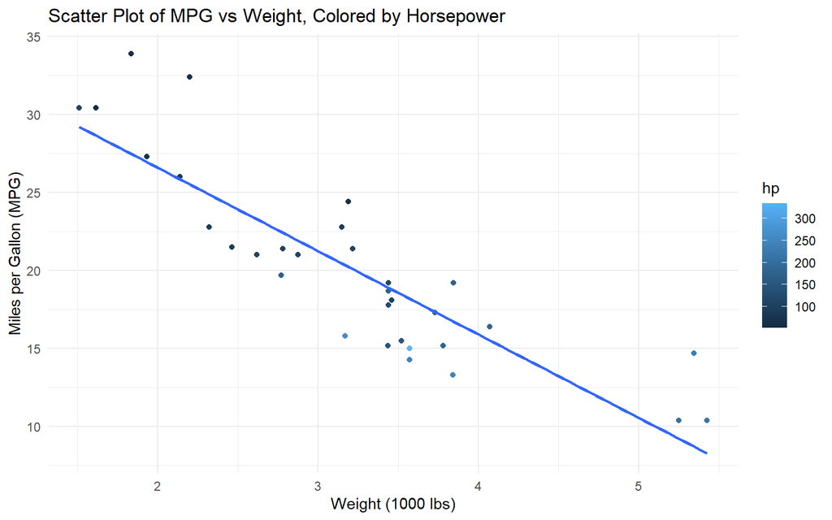

```r
# Scatter plot of mpg vs wt, colored by hp
ggplot(mtcars, aes(x = wt, y = mpg, color = hp)) +
  geom_point() +
  geom_smooth(method = "lm", se = FALSE) +
  labs(title = "Scatter Plot of MPG vs Weight, Colored by Horsepower",
       x = "Weight (1000 lbs)",
       y = "Miles per Gallon (MPG)") +
  theme_minimal()
```

# Exercises

## Exercise 1: Fit a Linear Model

Fit a linear model to predict `mpg` (miles per gallon) using `hp` (horsepower) and `wt` (weight) from the `mtcars` dataset. Display the summary of the model.

**Show Solution**

```r
# Fit the linear model
lm_model <- lm(mpg ~ hp + wt, data = mtcars)
summary(lm_model)
```

```
##
## Call:
## lm(formula = mpg ~ hp + wt, data = mtcars)
##
## Residuals:
##    Min     1Q Median     3Q    Max
## -3.941 -1.600 -0.182  1.050  5.854
##
## Coefficients:
##             Estimate Std. Error t value Pr(>|t|)
## (Intercept) 37.22727    1.59879  23.285  < 2e-16 ***
## hp          -0.03177    0.00903  -3.519  0.00145 **
## wt          -3.87783    0.63273  -6.129 1.12e-06 ***
## ---
## Signif. codes:  0 '***' 0.001 '**' 0.01 '*' 0.05 '.' 0.1 ' ' 1
##
## Residual standard error: 2.593 on 29 degrees of freedom
## Multiple R-squared:  0.8268, Adjusted R-squared:  0.8148
## F-statistic: 69.21 on 2 and 29 DF,  p-value: 9.109e-12
```

## Exercise 2: Residual Analysis

Plot the residuals of the linear model from Exercise 1.

**Show Solution**

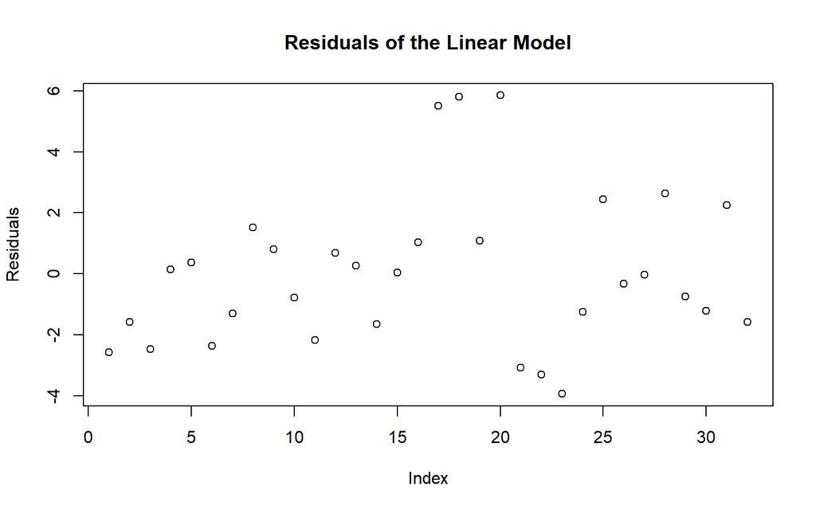

```r
# Solution
plot(lm_model$residuals, main = "Residuals of the Linear Model", xlab = "Index", ylab = "Residuals")
```

## Exercise 3: Predict New Values

Use the linear model to predict mpg for new data points where hp is 110 and wt is 2.5. Display the predicted values.

**Show Solution**

```r
# Solution
new_data <- data.frame(hp = 110, wt = 2.5)
predicted_mpg <- predict(lm_model, newdata = new_data)
predicted_mpg
```

```
##        1
## 24.03767
```

# Conclusion

In this document, we provided a detailed worked example of a linear model. We illustrated the null hypotheses in the summary of the model, how to compute the design matrix, the interpretation of the residual standard error, the null hypothesis of the F-statistic, the degrees of freedom, how to predict new values, and other relevant aspects to understand a linear model. This comprehensive overview should help in understanding the key components and interpretations of linear models in R.